# Assignment 8: Visualization - Making a bar race

*How to do it?*:

- Open the Rmarkdown file of this assignment (link) in Rstudio.
- Right under each **question**, insert a code chunk (you can use the hotkey `Ctrl + Alt + I` to add a code chunk) and code the solution for the question.
- `Knit` the rmarkdown file (hotkey: `Ctrl + Alt + K`) to export an html.
- Publish the html file to your Githiub Page.

*Submission*: Submit the link on Github of the assignment to Canvas

1. Install two packages `gganimate` and `gifski` then restart Rstudio. Using the `Adult Census Income` data, make an animation using `geom_point` and `transition_states`.

```r
install.packages(c("gganimate", "gifski"))
```

Run the installation once in the Console, then restart RStudio.

```r
library(tidyverse)
library(gganimate)
library(gifski)
```

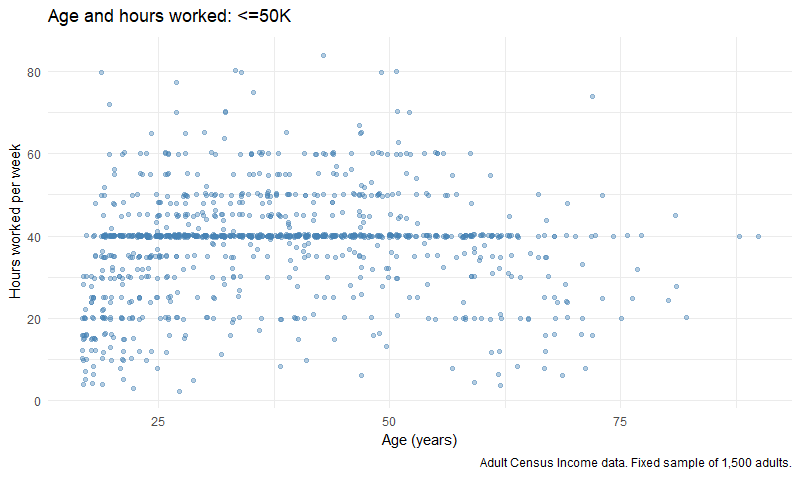

```r
adult <- read_csv("adult_census.csv", show_col_types = FALSE)

# Use a fixed random sample so the points are easier to see.
set.seed(421)
adult_sample <- adult %>%
  drop_na(age, hours.per.week, income) %>%
  slice_sample(n = 1500) %>%
  mutate(person = row_number(), income = factor(income))

adult_points <- adult_sample %>%
  ggplot(aes(x = age, y = hours.per.week, group = person)) +
  geom_point(alpha = 0.4, size = 1.6, color = "steelblue",
             position = position_jitter(width = 0.3, height = 0.3,
                                        seed = 421)) +
  transition_states(income, transition_length = 1, state_length = 3,
                    wrap = FALSE) +
  enter_fade() +
  exit_fade() +
  labs(title = "Age and hours worked: {closest_state}",
       x = "Age (years)", y = "Hours worked per week",
       caption = "Adult Census Income data. Fixed sample of 1,500 adults.") +
  theme_minimal()

animate(adult_points, nframes = 44, fps = 8,
        width = 800, height = 480, units = "px", res = 96,
        renderer = gifski_renderer())
```

Each point is one person. The animation switches between the two income groups while keeping the same axes. The points are slightly offset to show overlapping ages and work hours.

2. Using the `Adult Census Income` data, make an animation using `geom_bar` and `transition_states`.

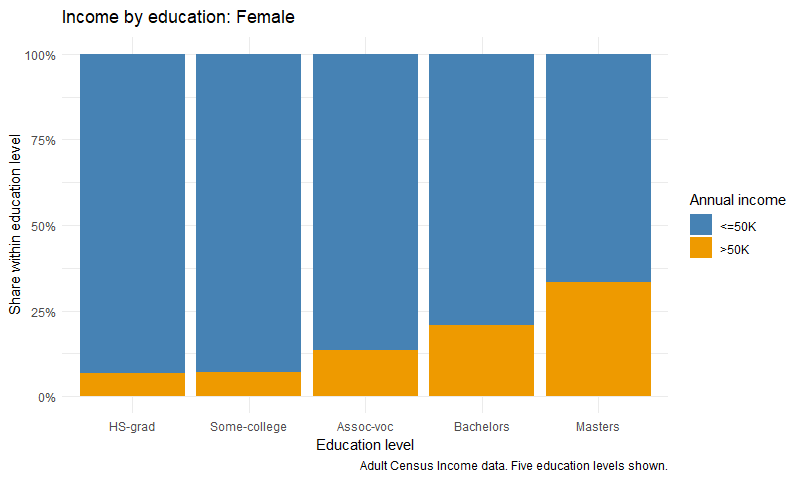

```r
education_levels <- c("HS-grad", "Some-college", "Assoc-voc",
                      "Bachelors", "Masters")

adult_education <- adult %>%
  filter(education %in% education_levels) %>%
  drop_na(sex, income) %>%
  mutate(education = factor(education, levels = education_levels))

adult_bars <- adult_education %>%
  ggplot(aes(x = education, fill = income)) +
  geom_bar(position = "fill") +
  scale_y_continuous(labels = scales::label_percent()) +
  scale_fill_manual(values = c("<=50K" = "steelblue", ">50K" = "orange2")) +
  transition_states(sex, transition_length = 1, state_length = 3,
                    wrap = FALSE) +
  labs(title = "Income by education: {closest_state}",
       x = "Education level", y = "Share within education level",
       fill = "Annual income",
       caption = "Adult Census Income data. Five education levels shown.") +
  theme_minimal()

animate(adult_bars, nframes = 44, fps = 8,
        width = 800, height = 480, units = "px", res = 96,
        renderer = gifski_renderer())
```

Each bar adds up to 100%. This lets us compare the share earning more than $50,000 across education levels as the animation switches between the recorded sex groups, even when the groups have different numbers of people.

3. Use the WHO’s dataset at [this link](https://bryantstats.github.io/math421/data/WHO-COVID-19-global-data.csv). Make a top-10 bar race by months between countries on the number of deaths by Covid 19 in 2021.

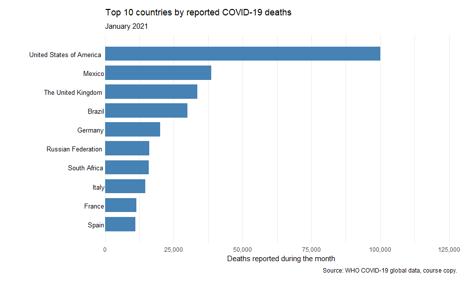

```r
who <- read_csv(
  "https://bryantstats.github.io/math421/data/WHO-COVID-19-global-data.csv",
  show_col_types = FALSE
)

who_top10 <- who %>%
  mutate(Date_reported = as.Date(Date_reported)) %>%
  filter(lubridate::year(Date_reported) == 2021) %>%
  filter(!is.na(New_deaths), !is.na(Country), Country != "") %>%
  mutate(month = lubridate::month(Date_reported, label = TRUE, abbr = FALSE)) %>%
  group_by(month, Country) %>%
  summarise(deaths = sum(New_deaths), .groups = "drop") %>%
  arrange(month, desc(deaths), Country) %>%
  group_by(month) %>%
  slice_head(n = 10) %>%
  mutate(rank = row_number()) %>%
  ungroup()

who_race <- who_top10 %>%
  ggplot(aes(x = deaths, y = 11 - rank, group = Country)) +
  geom_col(orientation = "y", width = 0.75, fill = "steelblue") +
  geom_text(aes(label = stringr::str_wrap(Country, 27)),
            x = 0, hjust = 1.05, size = 3.5, lineheight = 0.85) +
  scale_y_continuous(breaks = NULL, limits = c(0.5, 10.5)) +
  scale_x_continuous(labels = scales::label_comma(),
                     expand = expansion(mult = c(0, 0.06))) +
  coord_cartesian(clip = "off") +
  transition_states(month, transition_length = 0.5, state_length = 3,
                    wrap = FALSE) +
  enter_fade() +
  exit_fade() +
  labs(title = "Top 10 countries by reported COVID-19 deaths",
       subtitle = "{closest_state} 2021",
       x = "Deaths reported during the month", y = NULL,
       caption = "Source: WHO COVID-19 global data, course copy.") +
  theme_minimal() +
  theme(panel.grid.major.y = element_blank(),
        plot.margin = margin(12, 28, 12, 155))

animate(who_race, nframes = 96, fps = 8,
        width = 960, height = 570, units = "px", res = 96,
        renderer = gifski_renderer())
```

I summed `New_deaths` for each country and reporting month in 2021 and kept the ten largest totals each month. The bars show deaths reported during that month. Values between months are animation transitions.

4. Make a bar race using a dataset of your own interest. You may use the dataset that we use in class (https://bryantstats.github.io/math421/data/all-states-history.csv) but you should make a different bar racev from ones in the slides.

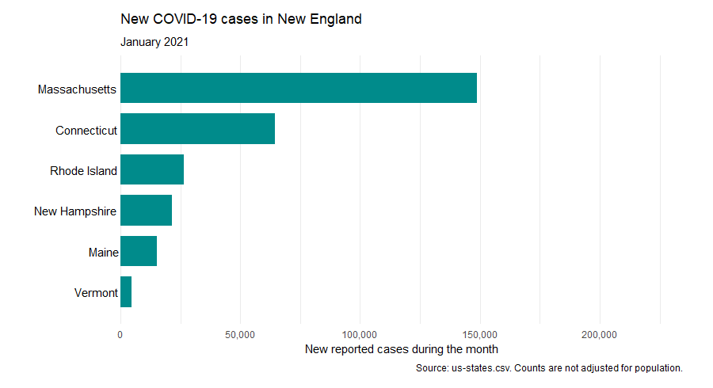

```r
us_states <- read_csv("us-states.csv", show_col_types = FALSE)
new_england <- c("Connecticut", "Maine", "Massachusetts",
                 "New Hampshire", "Rhode Island", "Vermont")

# The cases column is cumulative. Subtract consecutive month-end totals.
# Keep December 2020 so January 2021 has a starting total.
new_england_monthly <- us_states %>%
  mutate(date = lubridate::mdy(date)) %>%
  filter(state %in% new_england,
         date >= as.Date("2020-12-01"), date < as.Date("2022-01-01")) %>%
  mutate(month = lubridate::floor_date(date, "month")) %>%
  arrange(date) %>%
  group_by(state, month) %>%
  summarise(total_cases = last(cases), .groups = "drop") %>%
  arrange(state, month) %>%
  group_by(state) %>%
  mutate(new_cases = total_cases - lag(total_cases)) %>%
  ungroup() %>%
  filter(lubridate::year(month) == 2021) %>%
  arrange(month, desc(new_cases), state) %>%
  group_by(month) %>%
  mutate(rank = row_number(),
         month_name = lubridate::month(month, label = TRUE, abbr = FALSE)) %>%
  ungroup()

new_england_race <- new_england_monthly %>%
  ggplot(aes(x = new_cases, y = 7 - rank, group = state)) +
  geom_col(orientation = "y", width = 0.75, fill = "darkcyan") +
  geom_text(aes(label = state), x = 0, hjust = 1.05, size = 4) +
  scale_y_continuous(breaks = NULL, limits = c(0.5, 6.5)) +
  scale_x_continuous(labels = scales::label_comma(),
                     expand = expansion(mult = c(0, 0.06))) +
  coord_cartesian(clip = "off") +
  transition_states(month_name, transition_length = 0.5, state_length = 3,
                    wrap = FALSE) +
  labs(title = "New COVID-19 cases in New England",
       subtitle = "{closest_state} 2021",
       x = "New reported cases during the month", y = NULL,
       caption = "Source: us-states.csv. Counts are not adjusted for population.") +
  theme_minimal() +
  theme(panel.grid.major.y = element_blank(),
        plot.margin = margin(12, 28, 12, 110))

animate(new_england_race, nframes = 96, fps = 8,
        width = 900, height = 490, units = "px", res = 96,
        renderer = gifski_renderer())
```

This race compares all six New England states on new reported cases each month. Subtracting consecutive month-end counts makes it possible for a state’s bar to shrink when fewer new cases are reported. A state’s position shows its rank by case count, not its infection rate.